# Can NRT DGVMs improve the GCB land-sink projection?

15 September 2026

## Current GCB projection

For GCB2025, current-year SLAND was projected as the **residual of the other projected carbon-budget components**:

\[ S_{LAND}=E_{FOS}+E_{LUC}-G_{ATM}-S_{OCEAN} \]

**Question:** can near-real-time DGVM simulations provide an additional constraint?

*Global Carbon Budget 2025*, Sect. 2.6.2  
https://doi.org/10.5194/essd-18-3211-2026

## Two NRT DGVMs are now available

Two DGVM systems are available with near-real-time meteorology + seasonal forecast:

**JULES** and **ORCHIDEE**

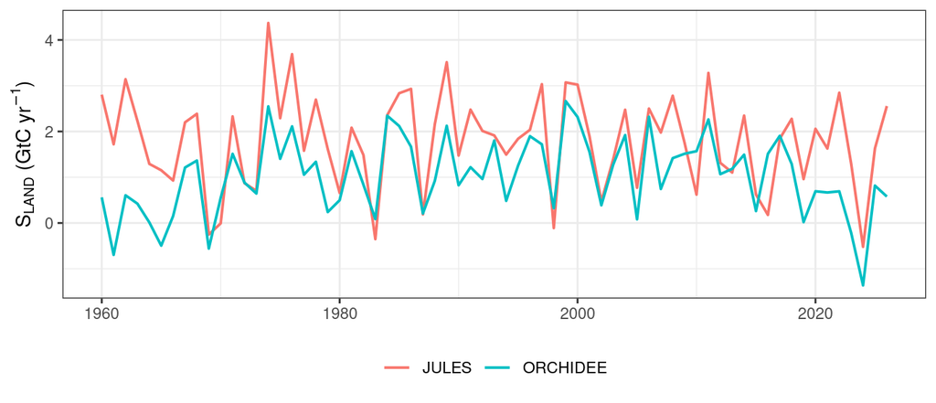

The proposed predictor is the **year-to-year change**, not absolute SLAND:

\[ \Delta S_{LAND,t}=S_{LAND,t}-S_{LAND,t-1} \]

## The two models show similar historical IAV

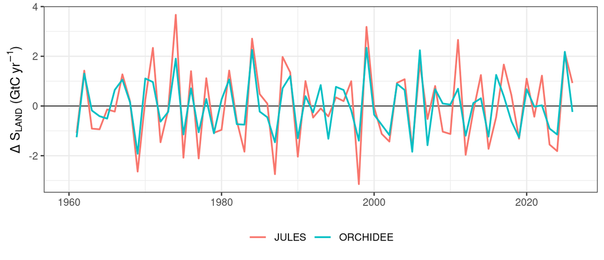

| Model | 2026 SLAND | 2025→2026 change |
| --- | --- | --- |
| JULES | 2.556 | 0.924 |
| ORCHIDEE | 0.578 | -0.239 |

The two-model mean change is **0.343 GtC yr⁻¹**.

JULES and ORCHIDEE disagree on the sign of the 2026 change, so the model spread should remain explicit.

## Does NRT ΔSLAND predict GCB ΔSLAND?

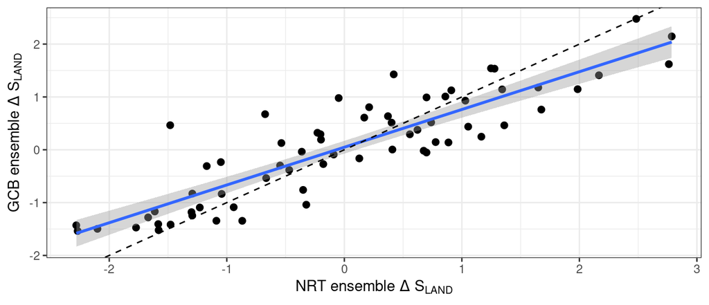

The two-model NRT mean annual change is strongly related to the annual change of the GCB DGVM ensemble.

- **r = 0.88**
- **R² = 0.77**
- **RMSE = 0.48 GtC yr⁻¹**

\[ \Delta S_{LAND}^{GCB} = 0.048 + 0.714 \Delta S_{LAND}^{NRT} \]

## 2026 predicted change

Two-model NRT mean:

\[ \Delta S_{LAND,2026}^{NRT} = 0.343\ \mathrm{GtC\,yr^{-1}} \]

Calibrated GCB change:

\[ \widehat{\Delta S}_{LAND,2026}^{GCB} = 0.293\ \mathrm{GtC\,yr^{-1}} \]

## Absolute 2026 estimate depends on the baseline

| 2025 baseline | 2025 SLAND | 2026 estimate | 95% PI lower | 95% PI upper |
| --- | --- | --- | --- | --- |
| GCB S2 (1700 land cover) | 4.43 | 4.72 | 3.74 | 5.71 |
| New GCB SLAND (S3-S4+S0) | 3.55 | 3.85 | 2.87 | 4.83 |

Historical GCB **S2** uses **1700 land cover**; the NRT runs use **2010 land cover**.

This year GCB also has a new SLAND definition:

\[ S_{LAND}^{new}=S3-S4+S0 \]

A practical approach is therefore:

**use the NRT DGVMs to estimate ΔSLAND, then apply that change to the preferred 2025 GCB SLAND baseline.**

The 2026 NRT mean suggests a modest increase, but the two models disagree on its sign.

Note, dL not included here yet.

## Does the prediction work?

As a simple hindcast, fit the NRT–GCB relationship using data only up to 2024, then ask what the JULES+ORCHIDEE 2024→2025 change would have predicted for the 2025 land sink.

Two model NRT mean (change in sink from 2024 to 2025): \[ \Delta S_{LAND,2025}^{NRT} = 2.166\ \mathrm{GtC\,yr^{-1}} \]

The NRT method predicts a 2025 land sink of **3.75 GtC yr⁻¹**, compared with the realised GCB value of **3.55 GtC yr⁻¹**.

Prediction interval: 2.74–4.77 GtC yr⁻¹.

So, starting from the 2024 GCB land sink, the NRT DGVM change successfully captures most of the large increase in SLAND observed in 2025.